# Explore Movie Dataset

## 探索电影数据集

在这个项目中，你将尝试使用所学的知识，使用 `NumPy`、`Pandas`、`matplotlib`、`seaborn` 库中的函数，来对电影数据集进行探索。

下载数据集： [TMDb电影数据](https://s3.cn-north-1.amazonaws.com.cn/static-documents/nd101/explore+dataset/tmdb-movies.csv)

数据集各列名称的含义：

| 列名称 | id | imdb_id | popularity | budget | revenue | original_title | cast | homepage | director | tagline | keywords | overview | runtime | genres | production_companies | release_date | vote_count | vote_average | release_year | budget_adj | revenue_adj |
| --- | --- | --- | --- | --- | --- | --- | --- | --- | --- | --- | --- | --- | --- | --- | --- | --- | --- | --- | --- | --- | --- |
| 含义 | 编号 | IMDB 编号 | 知名度 | 预算 | 票房 | 名称 | 主演 | 网站 | 导演 | 宣传词 | 关键词 | 简介 | 时常 | 类别 | 发行公司 | 发行日期 | 投票总数 | 投票均值 | 发行年份 | 预算（调整后） | 票房（调整后） |

**请注意，你需要提交该报告导出的 `.html`、`.ipynb` 以及 `.py` 文件。**

## 第一节 数据的导入与处理

在这一部分，你需要编写代码，使用 Pandas 读取数据，并进行预处理。

**任务1.1：** 导入库以及数据

1. 载入需要的库 `NumPy`、`Pandas`、`matplotlib`、`seaborn`。
2. 利用 `Pandas` 库，读取 `tmdb-movies.csv` 中的数据，保存为 `movie_data`。

提示：记得使用 notebook 中的魔法指令 `%matplotlib inline`，否则会导致你接下来无法打印出图像。

```python
import numpy as np
import pandas as pd
import matplotlib.pyplot as plt
import seaborn as sb

%matplotlib inline

movie_data = pd.read_csv('tmdb-movies.csv')
```

**任务1.2:** 了解数据

你会接触到各种各样的数据表，因此在读取之后，我们有必要通过一些简单的方法，来了解我们数据表是什么样子的。

1. 获取数据表的行列，并打印。
2. 使用 `.head()`、`.tail()`、`.sample()` 方法，观察、了解数据表的情况。
3. 使用 `.dtypes` 属性，来查看各列数据的数据类型。
4. 使用 `isnull()` 配合 `.any()` 等方法，来查看各列是否存在空值。
5. 使用 `.describe()` 方法，看看数据表中数值型的数据是怎么分布的。

```python
print(movie_data.shape)
```

```
(10866, 21)
```

```python
movie_data.head(3)  # 查看前3行数据
```

|  | id | imdb_id | popularity | budget | revenue | original_title | cast | homepage | director | tagline | ... | overview | runtime | genres | production_companies | release_date | vote_count | vote_average | release_year | budget_adj | revenue_adj |
| --- | --- | --- | --- | --- | --- | --- | --- | --- | --- | --- | --- | --- | --- | --- | --- | --- | --- | --- | --- | --- | --- |
| 0 | 135397 | tt0369610 | 32.985763 | 150000000 | 1513528810 | Jurassic World | Chris Pratt\|Bryce Dallas Howard\|Irrfan Khan\|Vi... | http://www.jurassicworld.com/ | Colin Trevorrow | The park is open. | ... | Twenty-two years after the events of Jurassic ... | 124 | Action\|Adventure\|Science Fiction\|Thriller | Universal Studios\|Amblin Entertainment\|Legenda... | 6/9/15 | 5562 | 6.5 | 2015 | 1.379999e+08 | 1.392446e+09 |
| 1 | 76341 | tt1392190 | 28.419936 | 150000000 | 378436354 | Mad Max: Fury Road | Tom Hardy\|Charlize Theron\|Hugh Keays-Byrne\|Nic... | http://www.madmaxmovie.com/ | George Miller | What a Lovely Day. | ... | An apocalyptic story set in the furthest reach... | 120 | Action\|Adventure\|Science Fiction\|Thriller | Village Roadshow Pictures\|Kennedy Miller Produ... | 5/13/15 | 6185 | 7.1 | 2015 | 1.379999e+08 | 3.481613e+08 |
| 2 | 262500 | tt2908446 | 13.112507 | 110000000 | 295238201 | Insurgent | Shailene Woodley\|Theo James\|Kate Winslet\|Ansel... | http://www.thedivergentseries.movie/#insurgent | Robert Schwentke | One Choice Can Destroy You | ... | Beatrice Prior must confront her inner demons ... | 119 | Adventure\|Science Fiction\|Thriller | Summit Entertainment\|Mandeville Films\|Red Wago... | 3/18/15 | 2480 | 6.3 | 2015 | 1.012000e+08 | 2.716190e+08 |

3 rows × 21 columns

```python
movie_data.tail(3)  # 查看后3行数据
```

|  | id | imdb_id | popularity | budget | revenue | original_title | cast | homepage | director | tagline | ... | overview | runtime | genres | production_companies | release_date | vote_count | vote_average | release_year | budget_adj | revenue_adj |
| --- | --- | --- | --- | --- | --- | --- | --- | --- | --- | --- | --- | --- | --- | --- | --- | --- | --- | --- | --- | --- | --- |
| 10863 | 39768 | tt0060161 | 0.065141 | 0 | 0 | Beregis Avtomobilya | Innokentiy Smoktunovskiy\|Oleg Efremov\|Georgi Z... | NaN | Eldar Ryazanov | NaN | ... | An insurance agent who moonlights as a carthie... | 94 | Mystery\|Comedy | Mosfilm | 1/1/66 | 11 | 6.5 | 1966 | 0.000000 | 0.0 |
| 10864 | 21449 | tt0061177 | 0.064317 | 0 | 0 | What's Up, Tiger Lily? | Tatsuya Mihashi\|Akiko Wakabayashi\|Mie Hama\|Joh... | NaN | Woody Allen | WOODY ALLEN STRIKES BACK! | ... | In comic Woody Allen's film debut, he took the... | 80 | Action\|Comedy | Benedict Pictures Corp. | 11/2/66 | 22 | 5.4 | 1966 | 0.000000 | 0.0 |
| 10865 | 22293 | tt0060666 | 0.035919 | 19000 | 0 | Manos: The Hands of Fate | Harold P. Warren\|Tom Neyman\|John Reynolds\|Dian... | NaN | Harold P. Warren | It's Shocking! It's Beyond Your Imagination! | ... | A family gets lost on the road and stumbles up... | 74 | Horror | Norm-Iris | 11/15/66 | 15 | 1.5 | 1966 | 127642.279154 | 0.0 |

3 rows × 21 columns

```python
movie_data.sample(3)  # 随机选择3行数据查看
```

|  | id | imdb_id | popularity | budget | revenue | original_title | cast | homepage | director | tagline | ... | overview | runtime | genres | production_companies | release_date | vote_count | vote_average | release_year | budget_adj | revenue_adj |
| --- | --- | --- | --- | --- | --- | --- | --- | --- | --- | --- | --- | --- | --- | --- | --- | --- | --- | --- | --- | --- | --- |
| 10147 | 11167 | tt0054167 | 0.569424 | 0 | 0 | Peeping Tom | Karlheinz BÃ¶hm\|Moira Shearer\|Anna Massey\|Maxi... | NaN | Michael Powell | marked for death by Peeping Tom - To Look Mean... | ... | A young man murders women, using a movie camer... | 101 | Horror\|Thriller | National Film Finance Corporation (NFFC)\|Anglo... | 4/6/60 | 56 | 7.4 | 1960 | 0.000000e+00 | 0.000000e+00 |
| 10711 | 24134 | tt0059084 | 0.168025 | 0 | 0 | Darling | Julie Christie\|Laurence Harvey\|Dirk Bogarde\|Jo... | NaN | John Schlesinger | Shame, shame, everybody knows your name! | ... | A beautiful but amoral model sleeps her way to... | 128 | Drama\|Romance | Vic Films Productions\|Joseph Janni Production | 8/3/65 | 16 | 5.8 | 1965 | 0.000000e+00 | 0.000000e+00 |
| 10115 | 821 | tt0055031 | 0.538364 | 3000000 | 10000000 | Judgment at Nuremberg | Spencer Tracy\|Burt Lancaster\|Richard Widmark\|M... | NaN | Stanley Kramer | The event the world will never forget. | ... | Judgment at Nuremberg is an American film base... | 186 | Drama\|History | United Artists\|Roxlom Films | 12/1/61 | 67 | 6.7 | 1961 | 2.188458e+07 | 7.294861e+07 |

3 rows × 21 columns

```python
movie_data.dtypes  ## 各列数据的数据类型
```

```
id                        int64
imdb_id                  object
popularity              float64
budget                    int64
revenue                   int64
original_title           object
cast                     object
homepage                 object
director                 object
tagline                  object
keywords                 object
overview                 object
runtime                   int64
genres                   object
production_companies     object
release_date             object
vote_count                int64
vote_average            float64
release_year              int64
budget_adj              float64
revenue_adj             float64
dtype: object
```

```python
movie_data.isnull().any()  ## 各列数据是否存在NaN
```

```
id                      False
imdb_id                  True
popularity              False
budget                  False
revenue                 False
original_title          False
cast                     True
homepage                 True
director                 True
tagline                  True
keywords                 True
overview                 True
runtime                 False
genres                   True
production_companies     True
release_date            False
vote_count              False
vote_average            False
release_year            False
budget_adj              False
revenue_adj             False
dtype: bool
```

```python
movie_data.describe()  ## 查看各列数据的统计性描述
```

|  | id | popularity | budget | revenue | runtime | vote_count | vote_average | release_year | budget_adj | revenue_adj |
| --- | --- | --- | --- | --- | --- | --- | --- | --- | --- | --- |
| count | 10866.000000 | 10866.000000 | 1.086600e+04 | 1.086600e+04 | 10866.000000 | 10866.000000 | 10866.000000 | 10866.000000 | 1.086600e+04 | 1.086600e+04 |
| mean | 66064.177434 | 0.646441 | 1.462570e+07 | 3.982332e+07 | 102.070863 | 217.389748 | 5.974922 | 2001.322658 | 1.755104e+07 | 5.136436e+07 |
| std | 92130.136561 | 1.000185 | 3.091321e+07 | 1.170035e+08 | 31.381405 | 575.619058 | 0.935142 | 12.812941 | 3.430616e+07 | 1.446325e+08 |
| min | 5.000000 | 0.000065 | 0.000000e+00 | 0.000000e+00 | 0.000000 | 10.000000 | 1.500000 | 1960.000000 | 0.000000e+00 | 0.000000e+00 |
| 25% | 10596.250000 | 0.207583 | 0.000000e+00 | 0.000000e+00 | 90.000000 | 17.000000 | 5.400000 | 1995.000000 | 0.000000e+00 | 0.000000e+00 |
| 50% | 20669.000000 | 0.383856 | 0.000000e+00 | 0.000000e+00 | 99.000000 | 38.000000 | 6.000000 | 2006.000000 | 0.000000e+00 | 0.000000e+00 |
| 75% | 75610.000000 | 0.713817 | 1.500000e+07 | 2.400000e+07 | 111.000000 | 145.750000 | 6.600000 | 2011.000000 | 2.085325e+07 | 3.369710e+07 |
| max | 417859.000000 | 32.985763 | 4.250000e+08 | 2.781506e+09 | 900.000000 | 9767.000000 | 9.200000 | 2015.000000 | 4.250000e+08 | 2.827124e+09 |

**任务1.3:** 清理数据

在真实的工作场景中，数据处理往往是最为费时费力的环节。但是幸运的是，我们提供给大家的 tmdb 数据集非常的「干净」，不需要大家做特别多的数据清洗以及处理工作。在这一步中，你的核心的工作主要是对数据表中的空值进行处理。你可以使用 `.fillna()` 来填补空值，当然也可以使用 `.dropna()` 来丢弃数据表中包含空值的某些行或者列。

任务：使用适当的方法来清理空值，并将得到的数据保存。

```python
## 'imdb_id', 'director', 'genres', 'revenue'这4列会对后续的分析造成影响，如果有NaN值，则删除行
movie_data.dropna(axis=0, subset=['imdb_id', 'director', 'genres', 'revenue'], inplace=True)

## 将其它的NaN替换为'XXX'
movie_data.fillna('XXX', inplace=True)
```

## 第二节 根据指定要求读取数据

相比 Excel 等数据分析软件，Pandas 的一大特长在于，能够轻松地基于复杂的逻辑选择合适的数据。因此，如何根据指定的要求，从数据表当获取适当的数据，是使用 Pandas 中非常重要的技能，也是本节重点考察大家的内容。

**任务2.1:** 简单读取

1. 读取数据表中名为 `id`、`popularity`、`budget`、`runtime`、`vote_average` 列的数据。
2. 读取数据表中前1～20行以及48、49行的数据。
3. 读取数据表中第50～60行的 `popularity` 那一列的数据。

要求：每一个语句只能用一行代码实现。

```python
## 数据表中名为 id、popularity、budget、runtime、vote_average 列的数据
data1 = movie_data[['id', 'popularity', 'budget', 'runtime', 'vote_average']]

## 数据表中前1～20行以及48、49行的数据
data2 = movie_data[1:21].append(movie_data[48:50])

## 数据表中第50～60行的 popularity 那一列的数据
data3 = movie_data[['popularity']][50:61]
```

**任务2.2:** 逻辑读取（Logical Indexing）

1. 读取数据表中 **`popularity` 大于5** 的所有数据。
2. 读取数据表中 **`popularity` 大于5** 的所有数据且**发行年份在1996年之后**的所有数据。

提示：Pandas 中的逻辑运算符如 `&`、`|`，分别代表`且`以及`或`。

要求：请使用 Logical Indexing实现。

```python
movie_popularity_greater_5 = movie_data[movie_data['popularity'] > 5]
movie_popularity_greater_5_release_year_after_1996 = movie_data[(movie_data['popularity'] > 5) & (movie_data['release_year'] > 1996)]
```

**任务2.3:** 分组读取

1. 对 `release_year` 进行分组，使用 [`.agg`](http://pandas.pydata.org/pandas-docs/version/0.22/generated/pandas.core.groupby.DataFrameGroupBy.agg.html) 获得 `revenue` 的均值。
2. 对 `director` 进行分组，使用 [`.agg`](http://pandas.pydata.org/pandas-docs/version/0.22/generated/pandas.core.groupby.DataFrameGroupBy.agg.html) 获得 `popularity` 的均值，从高到低排列。

要求：使用 `Groupby` 命令实现。

```python
mean_revenue_groupby_release_year = movie_data.groupby(['release_year'])['revenue'].agg(['mean'])
mean_popularity_groupby_director = movie_data.groupby(['director'])['popularity'].agg(['mean']).sort_values(by=['mean'], ascending=False)
```

## 第三节 绘图与可视化

接着你要尝试对你的数据进行图像的绘制以及可视化。这一节最重要的是，你能够选择合适的图像，对特定的可视化目标进行可视化。所谓可视化的目标，是你希望从可视化的过程中，观察到怎样的信息以及变化。例如，观察票房随着时间的变化、哪个导演最受欢迎等。

| 可视化的目标 | 可以使用的图像 |
| --- | --- |
| 表示某一属性数据的分布 | 饼图、直方图、散点图 |
| 表示某一属性数据随着某一个变量变化 | 条形图、折线图、热力图 |
| 比较多个属性的数据之间的关系 | 散点图、小提琴图、堆积条形图、堆积折线图 |

在这个部分，你需要根据题目中问题，选择适当的可视化图像进行绘制，并进行相应的分析。对于选做题，他们具有一定的难度，你可以尝试挑战一下～

**任务3.1：**对 `popularity` 最高的20名电影绘制其 `popularity` 值。

```
Text(0,0.5,'Popularity')
```

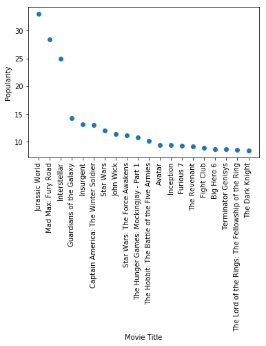

```python
## popularity最高的20名电影
max_20_popularity = movie_data.sort_values(by=['popularity'], ascending=False).head(20)
plt.scatter(data=max_20_popularity, x='original_title', y='popularity')
plt.xticks(rotation=90)
plt.xlabel('Movie Title')
plt.ylabel('Popularity')
```

**任务3.2：**分析电影净利润（票房-成本）随着年份变化的情况，并简单进行分析。

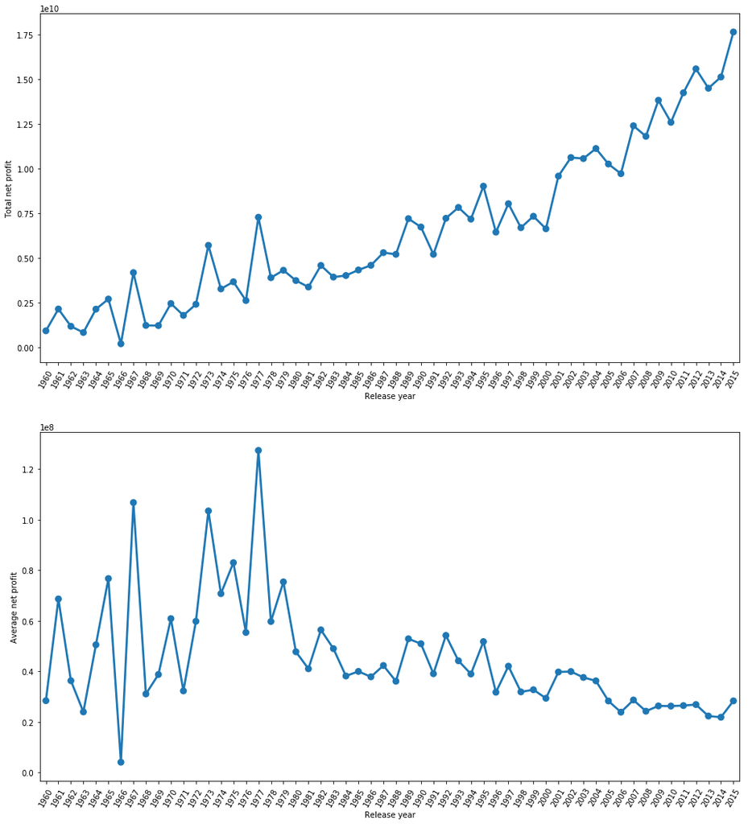

```python
## 统计年份-电影净利润
movie_data['net_profit'] = movie_data['revenue_adj'] - movie_data['budget_adj']  ## 增加净利润列net_profit

# 每年总的电影净利润
totoal_net_profit_by_year = movie_data[['release_year', 'net_profit']].groupby(['release_year']).agg('sum')
plt.figure(figsize=(16, 18))
plt.subplot(211)
sb.pointplot(data=totoal_net_profit_by_year, x=totoal_net_profit_by_year.index, y='net_profit')
plt.xticks(rotation=60);
plt.xlabel("Release year")
plt.ylabel('Total net profit')

# 每年电影的平均净利润
average_net_profit_by_year = movie_data[['release_year', 'net_profit']].groupby(['release_year']).agg('mean')
plt.subplot(212)
sb.pointplot(data=average_net_profit_by_year, x=average_net_profit_by_year.index, y='net_profit');
plt.xticks(rotation=60);
plt.xlabel("Release year");
plt.ylabel('Average net profit');
```

分析：

1. 每年票房总的净利润随着年份的增长处于上涨状态。
2. 每年票房每部电影的平均经理如并没有随着年份的增长而上涨，在1977年达到峰值后，随后处于一个缓慢下滑的状态。
3. 每年票房总的净利润增长是由于每年上映的电影越来越多的原因。